# Лабораторная работа №11

Управление загрузкой системы

Ришард Когенгар

Российский университет дружбы народов, Москва, Россия

21 января 2026

# Цель работы

## Основная цель

Получить практические навыки работы с загрузчиком GRUB2, изучить способы изменения параметров загрузки системы, диагностики неисправностей и восстановления доступа администратора.

# Ход выполнения работы

## Общая настройка загрузчика

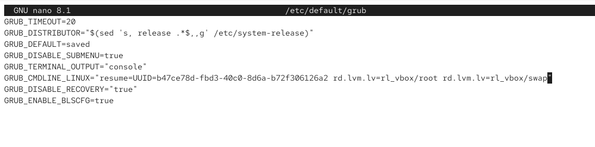

Редактирование файла /etc/default/grub

## Применение изменений

- Конфигурация GRUB2 пересобрана
- Обновлён файл `/boot/grub2/grub.cfg`
- Выполнена перезагрузка системы
- Подтверждено отображение меню GRUB
- Отключены параметры `rhgb` и `quiet` для вывода загрузочных сообщений

[figure not shown]

Меню загрузчика GRUB2

## Загрузка в rescue.target

- В меню GRUB выбран пункт с текущим ядром
- Выполнено редактирование параметров загрузки
- Добавлен параметр `systemd.unit=rescue.target`
- Удалены параметры скрытия загрузки

[figure not shown]

Загрузка в rescue.target

## Анализ состояния системы

- Выполнен вход под пользователем root
- Просмотрен список активных модулей systemd
- Установлено, что загружена минимальная рабочая среда
- Проанализированы переменные среды systemd

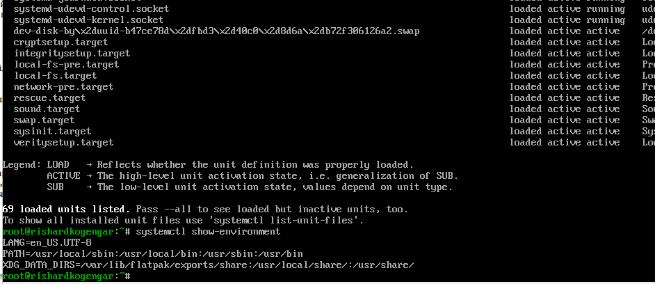

Анализ загруженных модулей

## Загрузка в emergency.target

- Повторное редактирование параметров GRUB
- Добавлен параметр `systemd.unit=emergency.target`
- Выполнена загрузка системы

[figure not shown]

Загрузка в emergency.target

## Минимальная среда

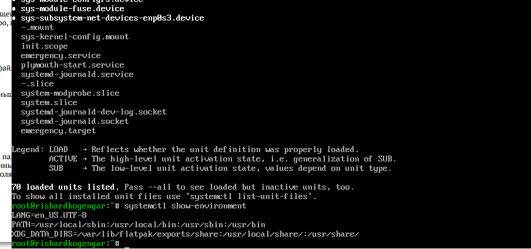

Минимальный набор модулей

## Использование rd.break

- В меню GRUB выполнено редактирование параметров ядра
- Добавлен параметр `rd.break`
- Загрузка остановлена на этапе initramfs

[figure not shown]

Добавление параметра rd.break

## Восстановление доступа

- Корневая файловая система перемонтирована в режиме записи
- Выполнен переход в окружение системы
- Установлен новый пароль root
- Восстановлены контексты SELinux
- Выполнена принудительная перезагрузка

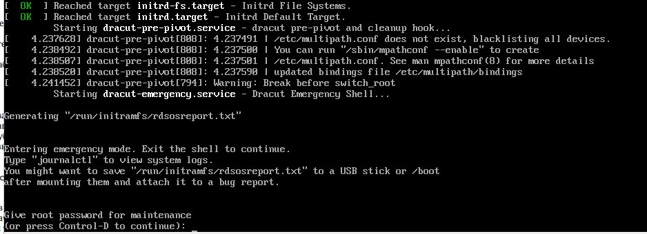

# Итоги работы

## Вывод

- Изучены принципы работы загрузчика GRUB2
- Освоено изменение параметров загрузки системы
- Выполнена загрузка в режимах rescue и emergency
- Получены навыки диагностики и восстановления системы
- Освоен безопасный сброс пароля пользователя root